# PCA - Analiza głównych składowych

Patryk Nizio

7 maja 2019

## PCA - wstęp

> Analiza składowych głównych (PCA) jest jedną z najbardziej popularnych metod redukcji wymiarów. Pozwala ona na sprowadzenie dużej liczby badanych zmiennych (zmienne pierwotne) do znacznie mniejszej liczby, wzajemnie niezależnych składowych głównych (czynników).

Suma zmienności zmiennych pierwotnych i wszystkich składowych głównych jest sobie równa. Największa część zmienności danych pierwotnych zgromadzona jest zwykle tylko w kilku pierwszych czynnikach.

Składowe główne są liniową kombinacją zmiennych pierwotnych i wygenerowane są w liczbie odpowiadającej liczbie składowych pierwotnych

## Zestaw danych - Iris

Zestaw danych “Iris” składa się z 50 próbek od każdego z trzech gatunków irysów (Iris setosa, Iris virginica i Iris versicolor). Z każdej próbki zmierzono cztery cechy: długość i szerokość działek i płatków w centymetrach.

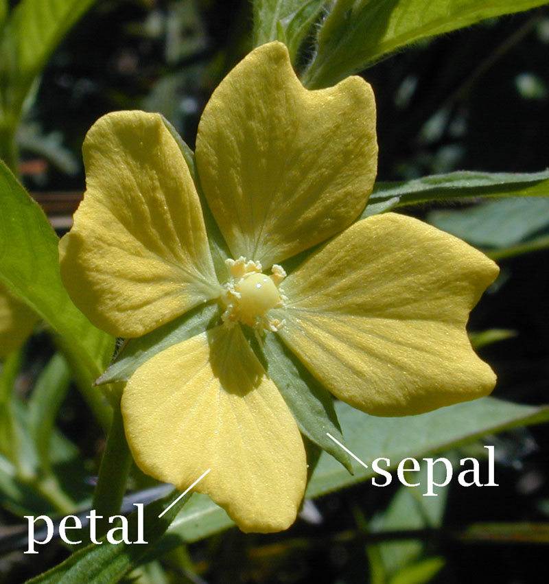

Flower with petal & sepal

Przykładowe dane:

```r
head(iris)
```

```
##   Sepal.Length Sepal.Width Petal.Length Petal.Width Species
## 1          5.1         3.5          1.4         0.2  setosa
## 2          4.9         3.0          1.4         0.2  setosa
## 3          4.7         3.2          1.3         0.2  setosa
## 4          4.6         3.1          1.5         0.2  setosa
## 5          5.0         3.6          1.4         0.2  setosa
## 6          5.4         3.9          1.7         0.4  setosa
```

Statystyki opisowe

```
##   Sepal.Length    Sepal.Width     Petal.Length    Petal.Width
##  Min.   :4.300   Min.   :2.000   Min.   :1.000   Min.   :0.100
##  1st Qu.:5.100   1st Qu.:2.800   1st Qu.:1.600   1st Qu.:0.300
##  Median :5.800   Median :3.000   Median :4.350   Median :1.300
##  Mean   :5.843   Mean   :3.057   Mean   :3.758   Mean   :1.199
##  3rd Qu.:6.400   3rd Qu.:3.300   3rd Qu.:5.100   3rd Qu.:1.800
##  Max.   :7.900   Max.   :4.400   Max.   :6.900   Max.   :2.500
##        Species
##  setosa    :50
##  versicolor:50
##  virginica :50
##
##
##
```

## Wizualizacja danych

Wykresy rozrzutu grupując po odmianie irysa:

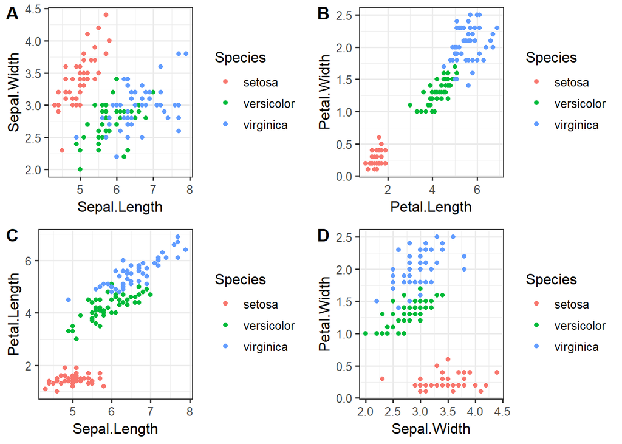

## PCA - analiza

**Korelacja**

```r
cor(iris[1:4], method = "pearson")
```

```
##              Sepal.Length Sepal.Width Petal.Length Petal.Width
## Sepal.Length    1.0000000  -0.1175698    0.8717538   0.8179411
## Sepal.Width    -0.1175698   1.0000000   -0.4284401  -0.3661259
## Petal.Length    0.8717538  -0.4284401    1.0000000   0.9628654
## Petal.Width     0.8179411  -0.3661259    0.9628654   1.0000000
```

**Wykres osypiska**

Jest to wykres liniowy wartości własnych. Po drugim czynniku następuje łągodny spadek, uwzględniamy najbardziej znaczące czynniki czyli pierwszy i drugi.

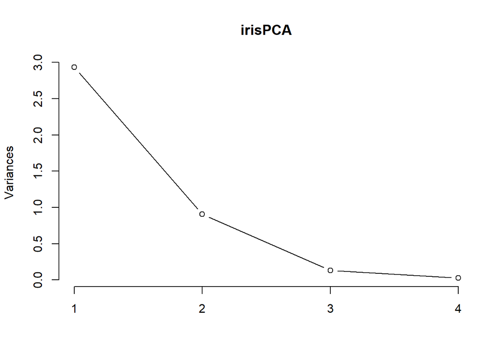

```r
species <- iris[, 5]
logIris <- log(iris[, 1:4])
irisPCA <- prcomp(logIris, center = TRUE, scale. = TRUE)
plot(irisPCA, type = "l")
```

Czynnik pierwszy jak widać na wykresie jest najbardziej znaczący. Natomiast pierwsze dwa czynniki odpowiadają za więcej niż 90% wariancji danych.

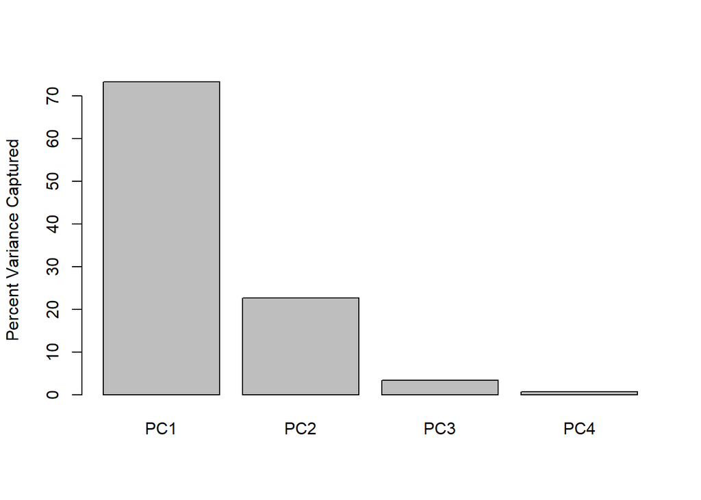

**Wyznaczenie wektorów własnych**

```r
irisPCA
```

```
## Standard deviations (1, .., p=4):
## [1] 1.7124583 0.9523797 0.3647029 0.1656840
##
## Rotation (n x k) = (4 x 4):
##                     PC1         PC2        PC3         PC4
## Sepal.Length  0.5038236 -0.45499872  0.7088547  0.19147575
## Sepal.Width  -0.3023682 -0.88914419 -0.3311628 -0.09125405
## Petal.Length  0.5767881 -0.03378802 -0.2192793 -0.78618732
## Petal.Width   0.5674952 -0.03545628 -0.5829003  0.58044745
```

**Wykres rozrzutu dla pierwszego i drugiego czynnika**

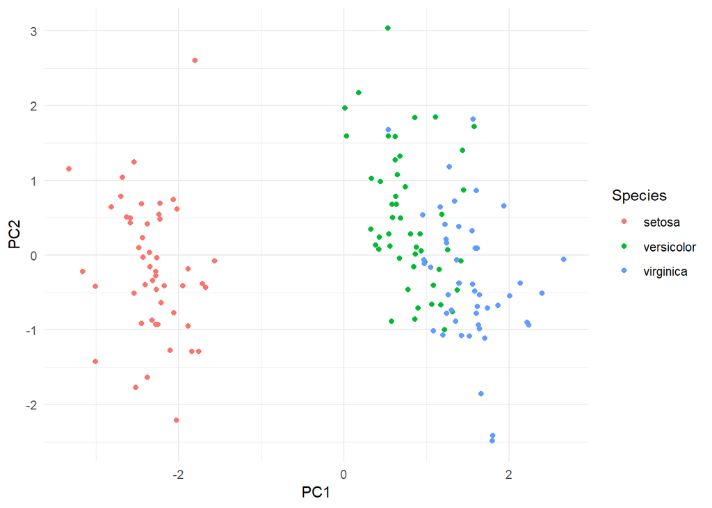

```r
pca_data <- data.frame(irisPCA$x, Species=iris$Species)
ggplot(pca_data, aes(x=PC1, y=PC2, color=Species)) + geom_point() +theme_minimal()
```

```r
# pca3 <- prcomp(iris[, 1:4])
# plot(x = pca3$x[, 1],
# y = pca3$x[, 2],
# pch = 16,
# col = rainbow(3)[iris$Species],
# xlab = "PC1",
# ylab = "PC2",
# main = "PCA of iris data")
```